# DHIS2 User Activity Analysis

### Analyzing user-level data for https://play.dhis2.org/2.31.3/.

DHIS2 keeps a log of every entry of a data element into a tracker program at the */trackedentitydatavalueaudit* API endpoint, including username and timestamp.

With these data, we can analyze user activity with tracker data elements, referred to as *interactions* in tables.

The selected dates for analysis are between 2014-01-21 and 2019-06-12

First, check to see that log in is valid.

```
## [1] "successfully logged in"
```

Now pull data on user activity from TEI audit log and pull user info from API.

|  | displayName | usernames | lastLogin |
| --- | --- | --- | --- |
| 6 | John Traore | admin | 2019-06-11T22:10:20.654 |
| 16 | Tom Wakiki | system | 2019-06-11T11:38:30.400 |
| 1 | John Barnes | android | 2019-06-11T09:15:32.464 |
| 17 | Tracker demo User | tracker | 2017-01-20T12:32:01.738 |
| 19 | John Kamara | district | 2016-08-05T19:17:01.991 |
| 15 | Kevin Boateng | boateng | 2016-08-02T10:14:10.457 |
| 13 | Seydou Keita | keita | 2016-06-28T11:14:25.503 |
| 9 | Thomas Nkono | nkono | 2015-03-12T10:33:57.932 |
| 14 | Didier Konan | konan | 2015-03-12T10:27:03.369 |
| 2 | Guest User | guest | 2014-10-07T22:17:43.434 |

[output cut: 9 more lines]

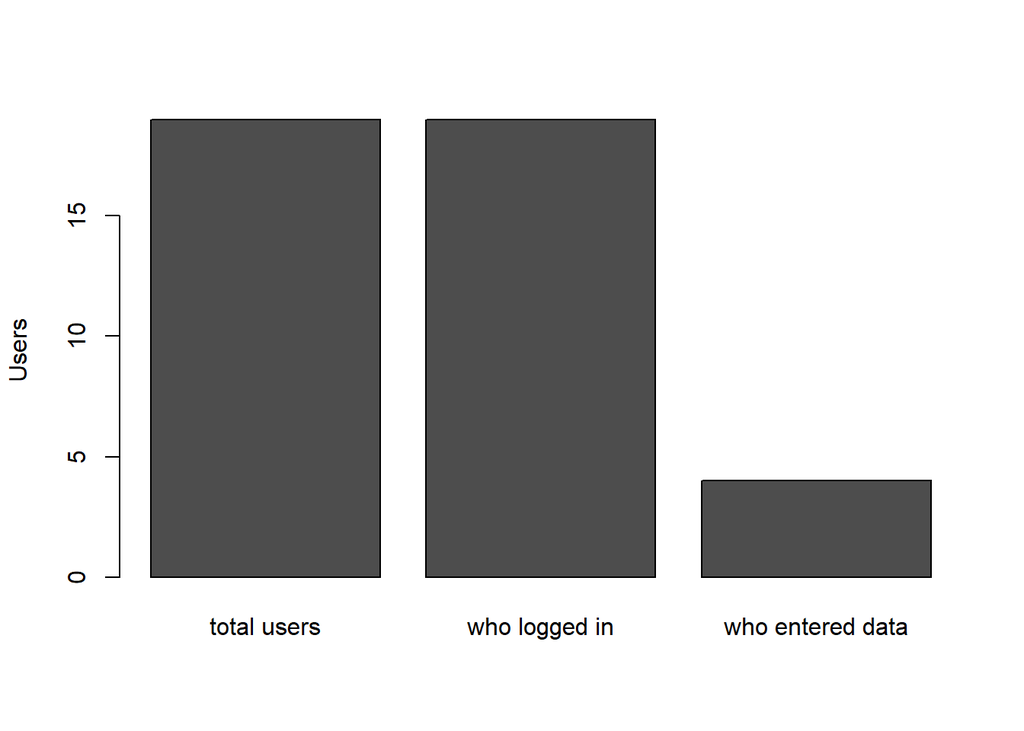

The audit log shows **9** unique program stages, entered by **4** unique users.

Overall, **19** users have accounts, and **19** have logged in at least once.

### Start Analysis of Tracker Audits

Program stages are listed below, by order of overall number of edits

|  | Stage | Interactions |
| --- | --- | --- |
| 1 | Inpatient morbidity and mortality | 2167 |
| 2 | First antenatal care visit | 132 |
| 3 | Antenatal care visit | 59 |
| 4 | TB visit | 48 |
| 5 | Birth | 28 |
| 6 | Sputum smear microscopy test | 14 |
| 7 | Lab monitoring | 10 |
| 8 | Baby Postnatal | 5 |
| 9 | Postpartum care visit | 5 |

This shows interactions by stage, for all users.

The figure after shows interactions by stage and hour, for all users.

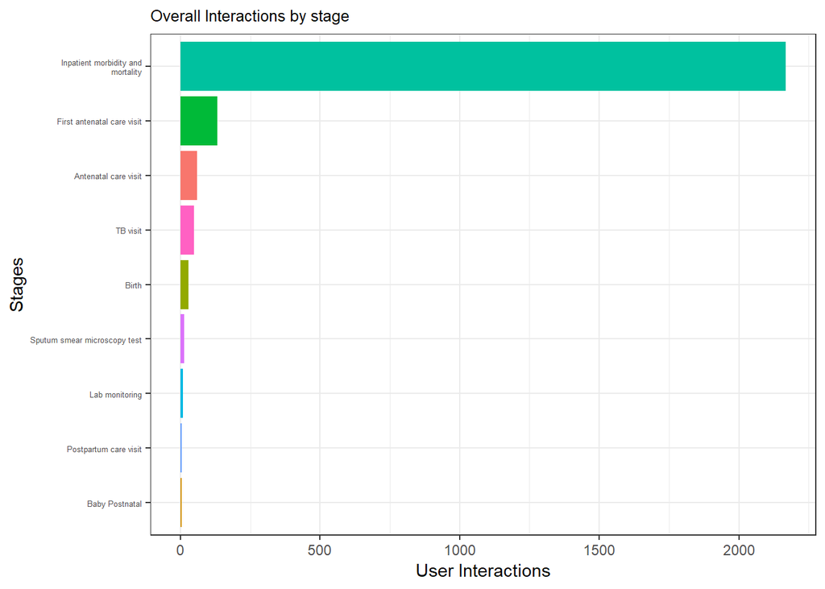

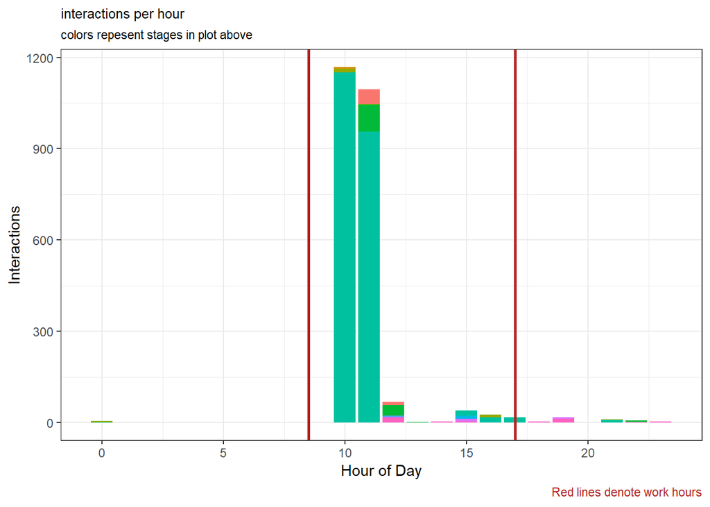

### User Group Analysis

Next, we will analyze by user group.

In total, **31** different user groups have entered tracker data.

Graph showing top stages by hour for each user group are found at directory C:/Users/Brian/Documents/GitHub/dhis2-user-analysis E.g. at C:/Users/Brian/Documents/GitHub/dhis2-user-analysis/usergroup_Wakiki.png

Below are the user groups with the most user interactions in tracker.

|  | group | interactions | during_work | percent_at_work |
| --- | --- | --- | --- | --- |
| 1 | _PROGRAM_Antenatalcareprogram | 618 | 561 | 0.91 |
| 2 | Administrators | 447 | 390 | 0.87 |
| 3 | AfricareHQ | 447 | 390 | 0.87 |
| 4 | FeedbackMessageRecipients | 447 | 390 | 0.87 |
| 5 | Malariaprogram | 447 | 390 | 0.87 |
| 6 | Systemadministrators | 447 | 390 | 0.87 |
| 7 | _DATASET_SystemadministratorALL | 429 | 379 | 0.88 |
| 8 | EPIStockCompletenessNotificationRecipients | 429 | 379 | 0.88 |
| 9 | _PROGRAM_SystemadministratorALL | 429 | 379 | 0.88 |
| 10 | Wakiki | 429 | 379 | 0.88 |

[output cut: 10 more lines]

### User Level Analysis

Last step is to print out same analysis for each individual user

Graphs showing top stages by hour for each username are found at directory C:/Users/Brian/Documents/GitHub/dhis2-user-analysis e.g. at C:/Users/Brian/Documents/GitHub/dhis2-user-analysis/user_tracker.png

Below are the usernames with the most freqent user interactions in tracker.

|  | user | interactions | during_work | percent_at_work |
| --- | --- | --- | --- | --- |
| 1 | [Unknown] | 1850 | 1842 | 1 |
| 2 | system | 429 | 379 | 0.88 |
| 3 | tracker | 171 | 171 | 1 |
| 4 | admin | 18 | 11 | 0.61 |